# Advanced-Statistics-With-R

Osman Merdan

2022-12-01

## 0.1 Loading Fundamental Libraries

```r
# Load the necessary libraries.
suppressMessages(library(tidyverse,ggplot))
suppressMessages(library(ggthemes,RColorBrewer))
suppressMessages(library(rstatix))
suppressMessages(library(ggpubr))
```

# 1 Correlation

### 1.0.1 Correlation vs Regression

- Major difference between correlation and regression is the purpose. Correlation tries to define relationship, regression is done for predictiong a value.
- Correlation does not imply causation.
- **Correlation** measures the relationship between two variables.
- **Regression** analysis is about how one variable affects another or what changes it causes to the other.
- Correlation captures the degree of interrelation between two variables.
- Regression is based on causality. It shows **no degree of connection** but **cause and effect**.
- In correlation ; p(X,Y)=p(Y,X), **correlation is symmetrical**.
- Regression is **one way analysis**.
- Linear regression analysis is known for the **best fitting line** that goes through the data points and **minimizes the distance** between them.
- Correlation is **a single point**.
- **Regression line** : the best fitting line through the data points
- The **slope of the regression line** is beta1.
- The **intercept** of the regression line with the y axis is beta0 and it is a constant.
- The distance between observed values and the regression line is **the estimator of the error**, epsilon.
- The estimate is called **residual**.
- Each time we create a regression that should be meaningful!
- **Linear Regression** : A linear approximation of a causal relationship between two or more variables. They are highly valuable as they are one of the most common ways to make inferences and predictions.
- Correlation is **scale independent**.
- Regression analysis is **scale dependent**.
- Slope of the regression line has the same sign as the correlation coefficient.
- If the correlation is zero, the regression line is horizontal with a slope of zero.
- An important consequence of scale independence in correlation is that the correlation between X and y is the same as the correlation between y^ and y. They are equal because the regression equation itself. y^ is a simple rescaling of X variable. (y^=a+bX)

### 1.0.2 Assumptions in Correlation

- Sample was randomly selected and the two variables, X and Y, vary together in a joint distribution that is normally distributed, called the bivariate normal distribution. Just because each variable is normally distributed when examined separately, however, does not guarantee that, jointly, they have a bivariate normal distribution.
- If either of the two variables is not normally distributed, Pearson’s product moment correlation coefficient is not the most appropriate method. - - Instead, either one or both of the variables may be transformed so that they more closely follow a normal distribution.
- Or Spearman rank correlation may be calculated.

### 1.0.3 Calculating Correlation

#### 1.0.3.1 The t test for Correlation

- The symbol for the correlation coefficient in the population (the population parameter) is p (lowercase Greek letter rho). In a random sample, p estimated by r.
- If several random samples of the same size are selected from a given population and the correlation coefficient r is calculated for each, we expect r to vary from one sample to another but to follow some sort of distribution about the population value p.

```r
# Prepare the data
Fat_data<-data.frame(
  read.csv("Kluess-plasma DPPIV-data.csv")
  )[,c("Participant..","BMI..kg.m2.","Percent.Fat","Sex")]
colnames(Fat_data)<-c("Participant", "BMI", "Percent.Fat","Sex")
psych::describe(Fat_data)
```

|  | vars | n | mean | sd | median | trimmed | mad | min | max | range | skew | kurtosis | se |
| --- | --- | --- | --- | --- | --- | --- | --- | --- | --- | --- | --- | --- | --- |
| Participant | 1 | 111 | 56.00000 | 32.1869539 | 56.0 | 56.000000 | 41.51280 | 1.0 | 111.0 | 110.0 | 0.0000000 | -1.232478 | 3.05505046 |
| BMI | 2 | 111 | 23.80360 | 3.7863614 | 23.2 | 23.489888 | 3.40998 | 17.5 | 37.1 | 19.6 | 0.9804412 | 1.372886 | 0.35938552 |
| Percent.Fat | 3 | 111 | 28.34324 | 8.7596557 | 29.1 | 28.458427 | 7.70952 | 7.0 | 51.2 | 44.2 | -0.1233753 | -0.173425 | 0.83142972 |
| Sex* | 4 | 111 | 1.36036 | 0.4822823 | 1.0 | 1.325843 | 0.00000 | 1.0 | 2.0 | 1.0 | 0.5738615 | -1.685626 | 0.04577621 |

```r
head(Fat_data)
```

|  | Participant | BMI | Percent.Fat | Sex |
| --- | --- | --- | --- | --- |
| 1 | 1 | 30.7 | 33.6 | F |
| 2 | 2 | 23.0 | 26.6 | F |
| 3 | 3 | 20.0 | 25.9 | F |
| 4 | 4 | 23.2 | 40.6 | F |
| 5 | 5 | 20.8 | 30.0 | F |
| 6 | 6 | 26.6 | 38.9 | F |

```r
# Checking for normality assumptions.
# OUTLIERS
rstatix::identify_outliers(data.frame(Fat_data$BMI))
```

| Fat_data.BMI | is.outlier | is.extreme |
| --- | --- | --- |
| 34.2 | TRUE | FALSE |
| 37.1 | TRUE | FALSE |
| 33.8 | TRUE | FALSE |
| 36.3 | TRUE | FALSE |

```r
rstatix::identify_outliers(data.frame(Fat_data$Percent.Fat))
```

| Fat_data.Percent.Fat | is.outlier | is.extreme |
| --- | --- | --- |
| 51.2 | TRUE | FALSE |

```r
# NORMALITY
shapiro_test(Fat_data$BMI)
```

| variable | statistic | p.value |
| --- | --- | --- |
| Fat_data$BMI | 0.9408133 | 9.401425e-05 |

```r
shapiro_test(Fat_data$Percent.Fat)
```

| variable | statistic | p.value |
| --- | --- | --- |
| Fat_data$Percent.Fat | 0.9918815 | 0.7572404 |

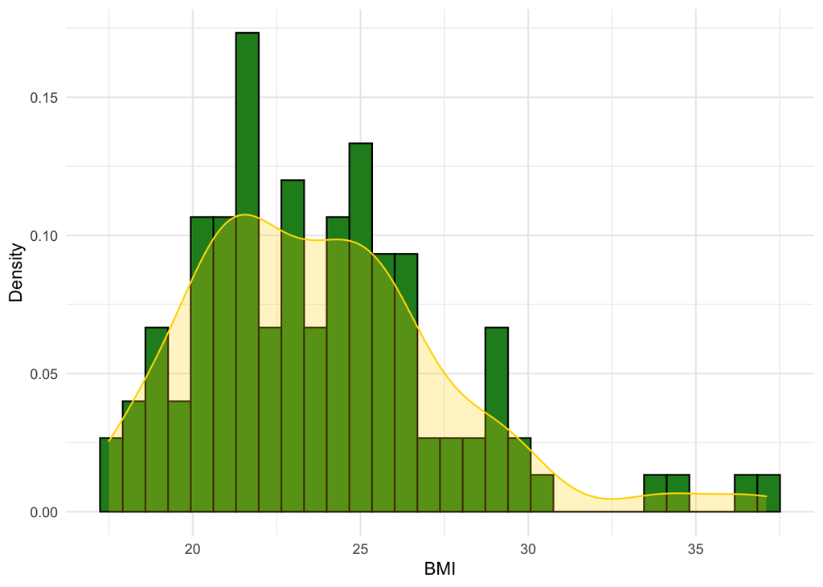

```r
# BMI values do not normally distributed.
# Percent.fat values are little bit better.

ggplot(data=Fat_data,aes(x=BMI))+
  geom_histogram(aes(y=..density..),
                 fill="forestgreen",
                 color="black")+
  geom_density(color="gold1",
               fill="gold1",
               alpha=0.25)+
  theme_minimal()+
  ylab("Density")
```

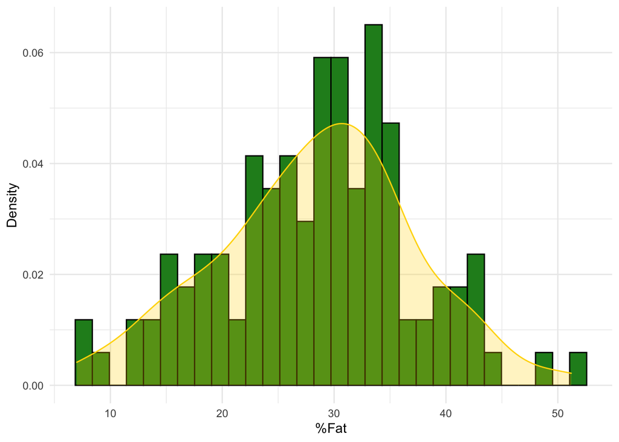

```r
ggplot(data=Fat_data,aes(x=Percent.Fat))+
  geom_histogram(aes(y=..density..),
                 fill="forestgreen",
                 color="black")+
  geom_density(color="gold1",
               fill="gold1",
               alpha=0.25)+
  theme_minimal()+
  ylab("Density")+
  xlab("%Fat")
```